# PRESS 2016 - COUNTRY FACTSHEETS

```
                                       Cabo Verde
```

Download this factsheet as PDF

The PRESS exercise is conducted annually to report on trends across time in support to statistics. The 2016 PRESS uses newly available data from an annual donor survey and the Creditor Reporting System (CRS) round of 2014 to update figures on aid to statistics for 2006 to 2013 (previously reported in the 2015 PRESS) and report new figures for commitments in 2014. The new 2014 figures are expected to be adjusted upwards to the levels of previous years 2011-2013 as additional projects for 2014 will be reported later this year.All findings should therefore be interpreted with this caveat in mind.

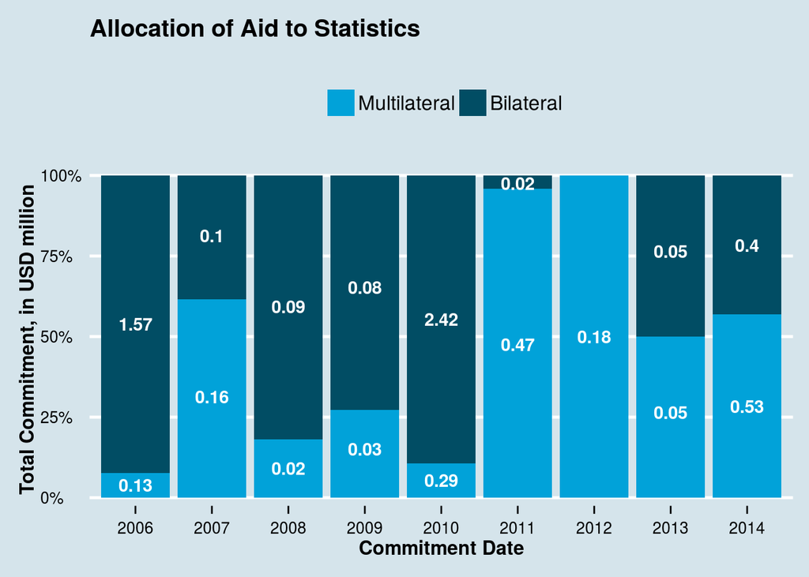

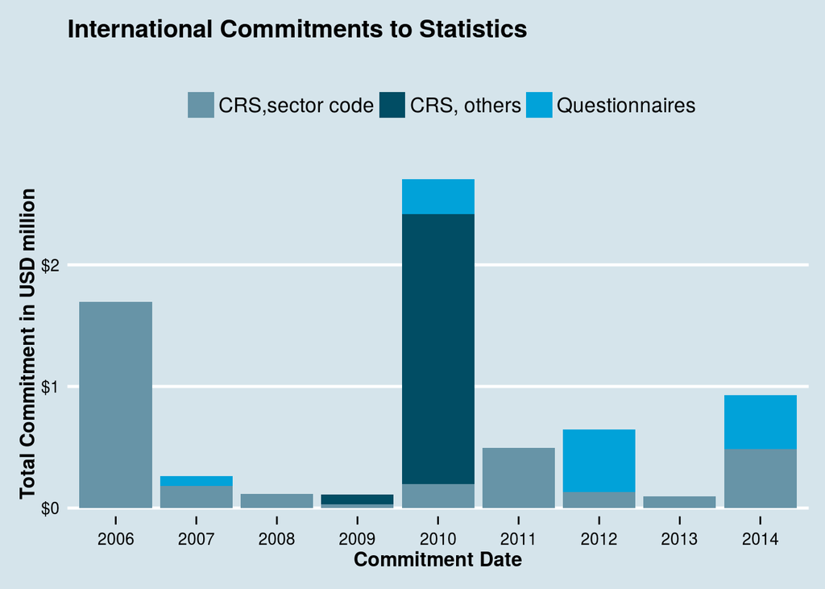

> Fig1. Allocation of Aid to Statistics

Multilateral[^1], country-specific assistance remains globally the most popular means through which donors channel support to countries. Considering all recipients reported in the PRESS, support from multilateral bodies accounted for less than 50% of total aid to statistics in 2009-2010 but increased to approximately 70% in 2011 and 2012, respectively. However, the shares of country-specific[^2] aid diminished slightly between 2012 and 2014.

> Fig2. International Commitments to Statistics

Support to statistics remains globally low. Considering all recipients reported in the PRESS, total 2014 commitments to statistical development of about USD 470 million show a 20% decrease from previous years 2011 and 2013. The decrease in commitments in 2014 led to a drop in the share of ODA dedicated to statistics from 0.31% in 2012 and 2013 to 0.25% in 2014. This should, however, not be interpreted as a general trend because commitments often span multiple years and fluctuations in annual figures are therefore common

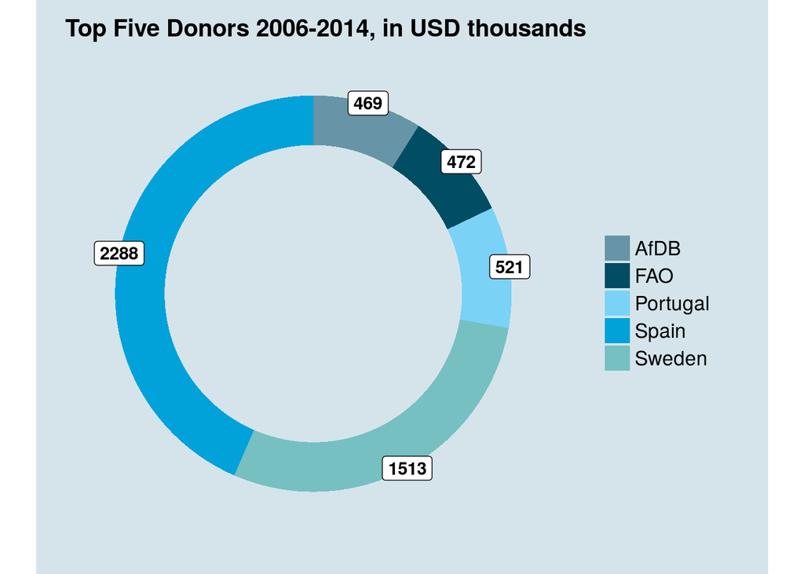

> Fig3. Top 5 Donors

A large share of global support to statistics continues to come from a very small number of providers. The top five providers of development co-operation in statistics for all countries reported in the PRESS (European Commission/EUROSTAT; The World Bank; IMF; FAO; Canada) provided 72% of total commitments in 2014. While Canada is strongly engaged in country-specific aid to statistics, the United Kingdom and Norway are among the top donors for unallocated commitments. Country-Specific commitments accounted for approximately 74% (USD 350 million) in 2014.

This table displays all projects whose Financing Amount is at least 10 000 USD.

| Provider | Projects | Amount | Type | Date |
| --- | --- | --- | --- | --- |
| **AfDB** | DATA CENTER PROJECT | 469 | Grant | 2011 |
| **EUROSTAT** | Support to poverty reduction and the implementation of the Action Plan for the Special Partnership between the European Union and Cape Verde. | 397 | Grant | 2014 |
| **FAO** | Assistance au renforcement du système de statistiques agricoles | 472 | Grant | 2012 |
| **IMF** | Technical Assistance | 78 |  | 2007 |
| **IMF** | Statistics Department: Technical Assistance | 45 |  | 2012 |
| **IMF** | Statistics Department: Technical Assistance | 47 |  | 2014 |
| **Luxembourg** | APPUI À L’INSTITUT NATIONAL DE STATISTIQUE | 398 | Grant | 2014 |
| **Portugal** | PRODUCTION OF STATISTICS | 31 | Grant | 2006 |
| **Portugal** | INSTITUTIONAL CAPACITY BUILDING IN THE AREA OF STATISTICS | 12 | Grant | 2006 |
| **Portugal** | STATISTICAL CAPACITY BUILDING | 41 | Grant | 2007 |
| **Portugal** | STATISTICAL CAPACITY BUILDING | 48 | Grant | 2007 |
| **Portugal** | SUPPORT TO THE DEVELOPMENT OF THE STATISTIC NATIONAL SYSTEMS IN THE PALOP - PIR PALOP II - 2ND REGIONAL INDICATIVE PROGRAMME FOR PALOP | 94 | Grant | 2008 |
| **Portugal** | PUBLIC SECTOR POLICY AND ADM. MANAGEMENT | 77 | Grant | 2009 |
| **Portugal** | COOPERATION IN THE AREA OF STATISTICS | 39 | Grant | 2010 |
| **Portugal** | COOPERATION IN THE AREA OF STATISTICS | 63 | Grant | 2010 |
| **Portugal** | COOPERATION IN THE AREA OF STATISTICS | 84 | Grant | 2010 |
| **Spain** | DEVELOPMENT OF A TERRITORIAL AND MUNICIPAL INFORMATION SYSTEM | 662 | Grant | 2010 |
| **Spain** | MINISTRU OF FINANCES. CENSUS 2010 | 1556 | Grant | 2010 |
| **Spain** | CIES PROGRAM STATISTICS INTERNATIONAL COOPERATION . | 25 | Grant | 2011 |
| **Spain** | CABO VERDE 2013 INSTITUTIONAL STRENGTHENING, MINISTRY OF FINANCE, NATIONAL STATISTICS INSTITUTE | 45 | Grant | 2013 |
| **Sweden** | NATIONAL STATISTICS OFFIC CAP VERDE INE | 21 | Grant | 2006 |
| **Sweden** | SCB-INE STATISTICS | 1492 | Grant | 2006 |
| **The World Bank** | Statistical Capacity Building in Cape Verde | 288 | Grant | 2010 |
| **UNDP** | STATISTICAL CAPACITY BUILDING | 132 | Grant | 2006 |
| **UNDP** | STATISTICAL CAPACITY BUILDING | 85 | Grant | 2007 |
| **UNDP** | SYSTEME STATISTIQUE NATIONAL R | 21 | Grant | 2008 |
| **UNDP** | SYSTEME STATISTIQUE NATIONAL R | 33 | Grant | 2009 |
| **UNDP** | RENFORCEMENT SYST NAT SATIST | 50 | Grant | 2013 |
| **UNDP** | RENFORCEMENT SYST NAT SATIST | 81 | Grant | 2014 |
| **UNICEF** | STATISTICAL SUPPORT | 60 | Grant | 2012 |
| **UNICEF** | STATISTICAL SUPPORT | 69 | Grant | 2012 |

**Source: PRESS 2016. The report was prepared by the Secretariat of the Partnership in Statistics for Development in the 21st Century (PARIS21)**

[^1]: Multilateral support in this context refers to support coming from multilateral institutions.
[^2]: Country-specific assistance refers to projects for which there is a single country recipient.